# Bootstrapping方法

LJJ

2020/4/16

## boot

自助法的优点之一是它几乎可以被用于所有情形，而并不要求复杂的数学计算。在R中使用自助法只需要两个步骤。第一，创建一个计算感兴趣的统计盘的函数。第二，用boot包中的 boot()函数，通过反复地从数据集中有放回地抽取观测值来执行自助法。

```r
library(tidyverse)
library(skimr)
library(boot)
library(ISLR)
```

## 估计统计量的精度

```r
data("Portfolio")
```

```r
Portfolio %>% skimr::skim() -> data_sum
data_sum
```

Data summary

| Name | Piped data |
| --- | --- |
| Number of rows | 100 |
| Number of columns | 2 |
| _______________________ |  |
| Column type frequency: |  |
| numeric | 2 |
| ________________________ |  |
| Group variables | None |

**Variable type: numeric**

| skim_variable | n_missing | complete_rate | mean | sd | p0 | p25 | p50 | p75 | p100 | hist |
| --- | --- | --- | --- | --- | --- | --- | --- | --- | --- | --- |
| X | 0 | 1 | -0.08 | 1.06 | -2.43 | -0.89 | -0.27 | 0.56 | 2.46 | ▂▇▇▅▂ |
| Y | 0 | 1 | -0.10 | 1.14 | -2.73 | -0.89 | -0.23 | 0.81 | 2.57 | ▂▆▇▇▂ |

```r
Portfolio %>% head()
```

```
##            X          Y
## 1 -0.8952509 -0.2349235
## 2 -1.5624543 -0.8851760
## 3 -0.4170899  0.2718880
## 4  1.0443557 -0.7341975
## 5 -0.3155684  0.8419834
## 6 -1.7371238 -2.0371910
```

```r
alpha_fn <- function(data,index){
  X = data$X[index]
  Y = data$Y[index]
  return((var(Y) - cov(X,Y))/(var(X) + var(Y) - 2*cov(X,Y)))
}
```

```r
alpha_fn(Portfolio,1:100)  # 真实参数
```

```
## [1] 0.5758321
```

下面的命令用 sample()函数来随机地从 1 到 100 中有放回地选取 100 个观测。这稳当于创建了一个新的自助法数据集，然后在新的数据袋上重新计算$\hat\alpha$.

```r
set.seed(123)
alpha_fn(Portfolio,sample(100,100,replace = TRUE))
```

```
## [1] 0.6618485
```

```r
boot(Portfolio,alpha_fn,R = 1000)
```

```
##
## ORDINARY NONPARAMETRIC BOOTSTRAP
##
##
## Call:
## boot(data = Portfolio, statistic = alpha_fn, R = 1000)
##
##
## Bootstrap Statistics :
##      original      bias    std. error
## t1* 0.5758321 0.007540109   0.0895633
```

## 估计线性回归模型的精度

```r
boot_fn <- function(data,index){
  return(coef(lm(mpg ~ horsepower,data = data,subset = index)))
}
```

```r
boot_fn(data = Auto,index = 1:392)
```

```
## (Intercept)  horsepower
##  39.9358610  -0.1578447
```

```r
set.seed(1)
boot_fn(Auto,sample(392,392,replace = TRUE))
```

```
## (Intercept)  horsepower
##  40.3404517  -0.1634868
```

```r
boot(Auto,boot_fn,1000)->boot_result
boot.ci(boot_result,type = "bca")
```

```
## BOOTSTRAP CONFIDENCE INTERVAL CALCULATIONS
## Based on 1000 bootstrap replicates
##
## CALL :
## boot.ci(boot.out = boot_result, type = "bca")
##
## Intervals :
## Level       BCa
## 95%   (38.47, 41.65 )
## Calculations and Intervals on Original Scale
```

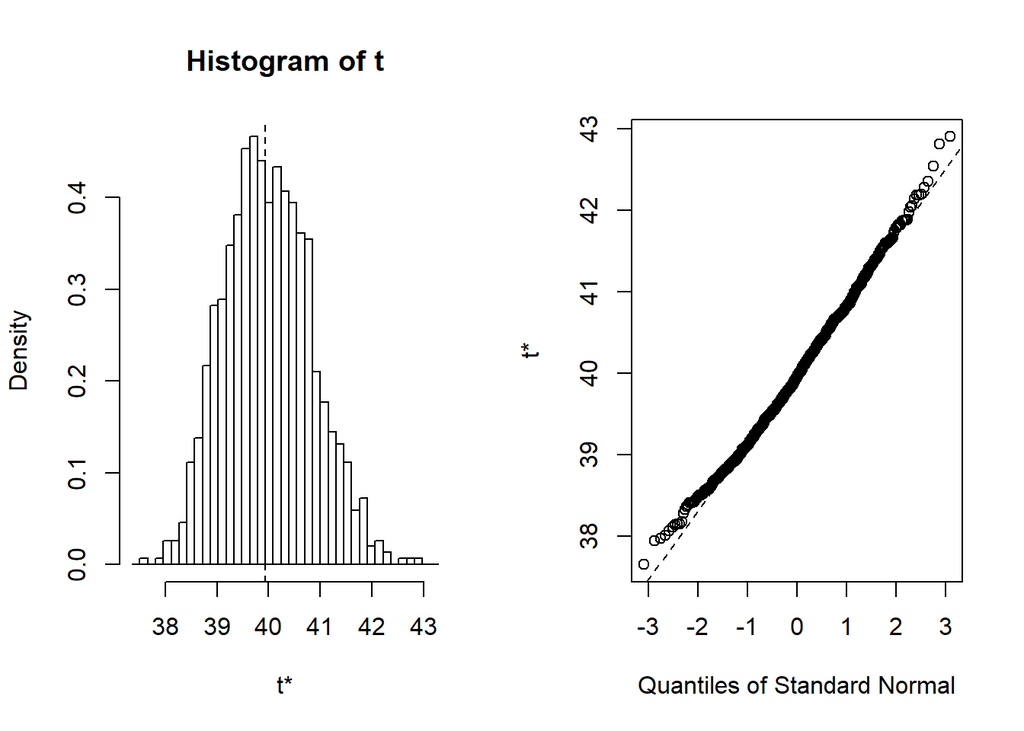

```r
plot(boot_result)
```

```r
lm(mpg ~ horsepower,data = Auto) %>% broom::tidy()
```

```
## # A tibble: 2 x 5
##   term        estimate std.error statistic   p.value
##   <chr>          <dbl>     <dbl>     <dbl>     <dbl>
## 1 (Intercept)   39.9     0.717        55.7 1.22e-187
## 2 horsepower    -0.158   0.00645     -24.5 7.03e- 81
```

## 来自quick R的案例分析

```r
# Bootstrap 95% CI for R-Squared
# function to obtain R-Squared from the data
rsq <- function(formula, data, indices) {
  d <- data[indices, ] # allows boot to select sample
  fit <- lm(formula, data = d)
  return(summary(fit)$r.square)
}

# bootstrapping with 1000 replications
results <- boot(
  data = mtcars,  # 数据
  statistic = rsq, # 函数
  R = 1000, # boot数目
  formula = mpg ~ wt + disp  # 公式
)

# view results
results
```

```
##
## ORDINARY NONPARAMETRIC BOOTSTRAP
##
##
## Call:
## boot(data = mtcars, statistic = rsq, R = 1000, formula = mpg ~
##     wt + disp)
##
##
## Bootstrap Statistics :
##      original     bias    std. error
## t1* 0.7809306 0.01083986  0.04952658
```

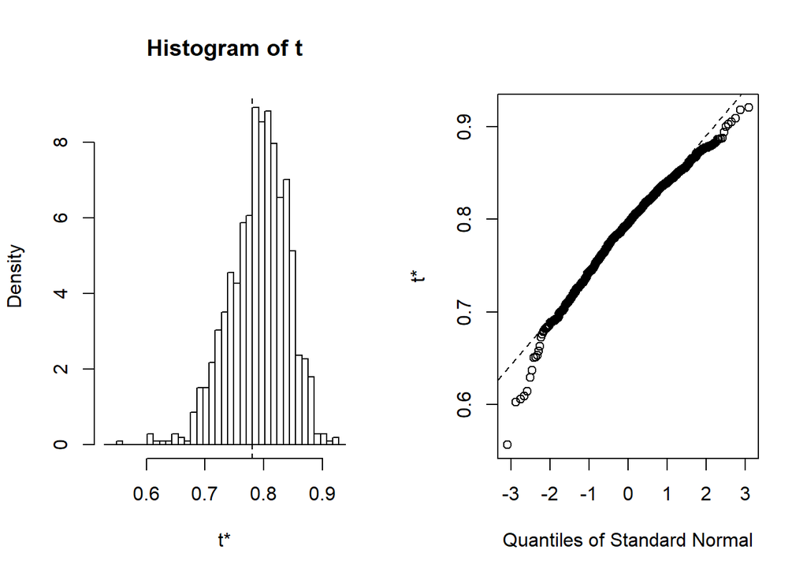

```r
plot(results)
```

```r
# get 95% confidence interval
boot.ci(results, type = "bca")
```

```
## BOOTSTRAP CONFIDENCE INTERVAL CALCULATIONS
## Based on 1000 bootstrap replicates
##
## CALL :
## boot.ci(boot.out = results, type = "bca")
##
## Intervals :
## Level       BCa
## 95%   ( 0.6086,  0.8502 )
## Calculations and Intervals on Original Scale
## Some BCa intervals may be unstable
```

在上面的例子中，函数rsq返回一个数字并启动。ci返回单个置信区间。您提供的统计函数也可以返回一个向量。在下一个例子中，我们得到了三个模型回归系数(截距、汽车重量、位移)的95% CI。在本例中，我们向plot()和boot添加了一个索引参数。ci()表示要分析bootobject$t中的哪一列。

```r
# function to obtain regression weights
bs <- function(formula, data, indices) {
  d <- data[indices, ] # allows boot to select sample
  fit <- lm(formula, data = d)
  return(coef(fit))
}

# bootstrapping with 1000 replications
results <- boot(
  data = mtcars,
  statistic = bs,
  R = 1000,
  formula = mpg ~ wt + disp
)

# view results
results
```

```
##
## ORDINARY NONPARAMETRIC BOOTSTRAP
##
##
## Call:
## boot(data = mtcars, statistic = bs, R = 1000, formula = mpg ~
##     wt + disp)
##
##
## Bootstrap Statistics :
##        original        bias    std. error
## t1* 34.96055404  1.431736e-01 2.500091845
## t2* -3.35082533 -6.048415e-02 1.158023066
## t3* -0.01772474 -7.638366e-06 0.008370535
```

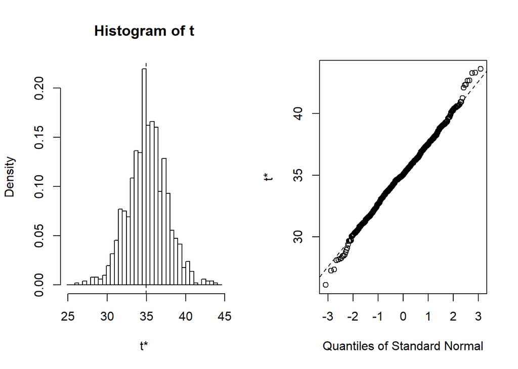

```r
plot(results, index = 1) # intercept
```

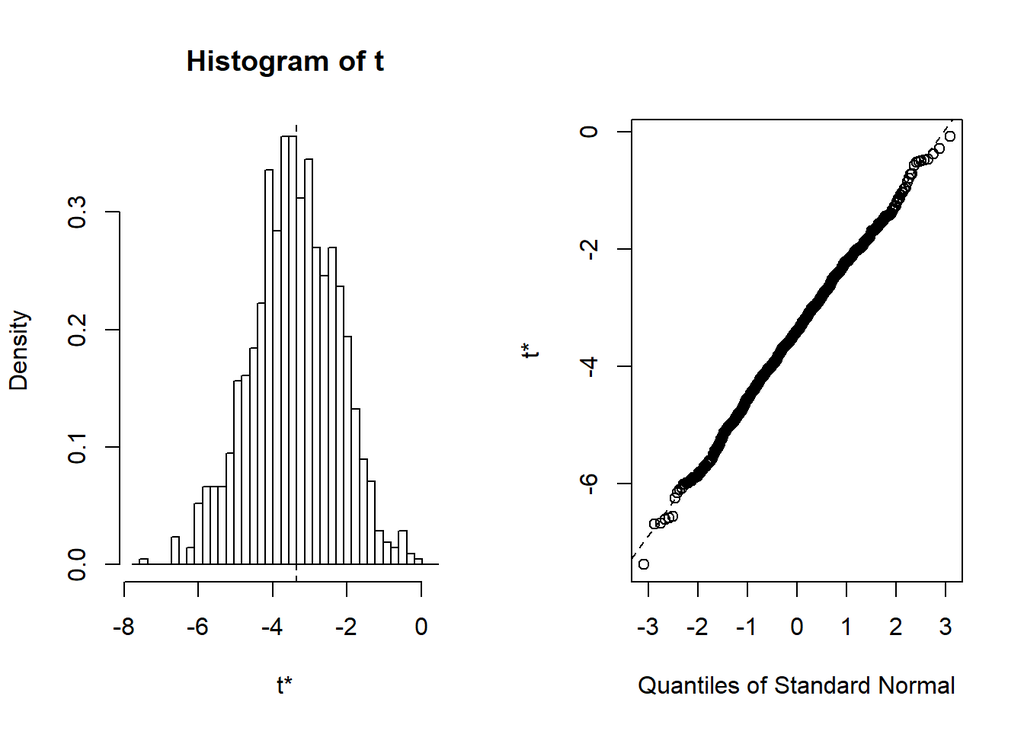

```r
plot(results, index = 2) # wt
```

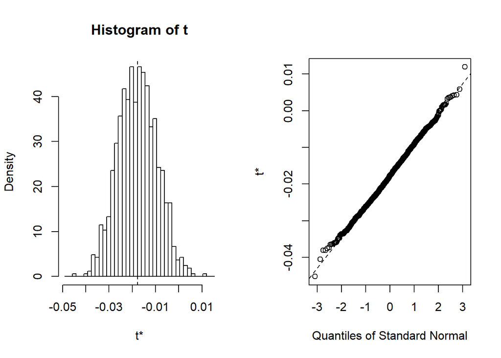

```r
plot(results, index = 3) # disp
```

```r
# get 95% confidence intervals
boot.ci(results, type = "bca", index = 1) # intercept
```

```
## BOOTSTRAP CONFIDENCE INTERVAL CALCULATIONS
## Based on 1000 bootstrap replicates
##
## CALL :
## boot.ci(boot.out = results, type = "bca", index = 1)
##
## Intervals :
## Level       BCa
## 95%   (29.96, 39.71 )
## Calculations and Intervals on Original Scale
```

```r
boot.ci(results, type = "bca", index = 2) # wt
```

```
## BOOTSTRAP CONFIDENCE INTERVAL CALCULATIONS
## Based on 1000 bootstrap replicates
##
## CALL :
## boot.ci(boot.out = results, type = "bca", index = 2)
##
## Intervals :
## Level       BCa
## 95%   (-5.656, -1.032 )
## Calculations and Intervals on Original Scale
```

```r
boot.ci(results, type = "bca", index = 3) # disp
```

```
## BOOTSTRAP CONFIDENCE INTERVAL CALCULATIONS
## Based on 1000 bootstrap replicates
##
## CALL :
## boot.ci(boot.out = results, type = "bca", index = 3)
##
## Intervals :
## Level       BCa
## 95%   (-0.0335, -0.0010 )
## Calculations and Intervals on Original Scale
```

boot()函数可以生成非参数重采样和参数重采样。对于非参数bootstrap，重采样方法包括普通重采样法、平衡重采样法、对偶重采样法和置换重采样法。对于非参数引导，支持分层重采样。还可以指定重采样权值的重要性。

## 更多资源

参见[Quick R](https://www.statmethods.net/advstats/bootstrapping.html)